# Data Wrangling

### Data wrangling:

- Split-Apply-Combine operations
- Long and Wide data
- Joins
- Quick-and-dirty tables and plots
- Recoding

### Tidyverse conventions

We’ll make extensive use of `tidyverse` packages for these sections.

Some genre conventions of tidy code

1. Most functions take a `.data =` argument. Which means so they work well with `|>` and you’ll rarely see `$` notation.
2. A preference for `tidy` data, where each row represents a single case or observation, each column is a variable, and each cell contains a single value.
3. Some stylistic regularities: like related functions having a `prefix_suffix` naming style. Ex: `str_split`, `str_replace`, and `str_extract`

### Problem

I’ve got a collection of “candidate events” from the UCDP. Here’s an example of the formatting:

- My raw data is measured at the event level
- But I want to aggregate data by country

| country | conflict_name | date_start | source_headline | deaths_civilians |
| --- | --- | --- | --- | --- |
| Mexico | Jalisco Cartel New Generation - Civilians | 2025-04-24 | Condena Segob ejecución | 2 |
| Ukraine | Russia - Ukraine | 2025-05-22 | In Aleshki, a civilian died during shelling by the Ukrainian Armed Forces | 1 |
| Ukraine | Russia - Ukraine | 2025-02-21 | One person died and four were injured in shelling in the Kherson region within a day | 1 |
| Mozambique | IS - Civilians | 2025-05-11 | Cabo Ligado Update: 5 — 18 May 2025;IS-linked group abducting children in Mozambique: HRW | 3 |
| Burundi | XXX516 - Civilians | 2025-03-12 | Bulletin hebdomadaire Iteka n’Ijambo n°465 | 1 |

### Split-Apply-Combine operations

- Many analyses will require some variation on this basic pattern:
- **Split** data into meaningful groups
- **Apply** some statistical calculation for each group (average, range, variance, etc.)
- **Combine** the results into a new summary table
- while these sorts of operations could be performed in a loop, or using base functions like `aggregate`, we’ll use the `dplyr` package here

### Split-Apply-Combine

[figure not shown]

Example of split-apply-combine process for a group-wise average

### dplyr: group_by

**`group_by(.data, ...)`**

Turns `.data` into a grouped table where each group is defined by the variables listed in `...`

- This doesn’t do much on its own, but subsequent dplyr functions will be performed on the groups you’ve created. You can think of this as the “split” step.

```r
library(dplyr)
df<-data.frame(group = c("A", "A", "A", "A",
                         "B", "B",  "B", "B",
                         "C", "C", "C"),
               value = c(3, 3, 5, 7, 2, 1, 1,9, 2, 1, 1)
               )

df_grouped<-df|>
  group_by(group)


# data looks the same after this step:
df_grouped
```

```
# A tibble: 11 × 2
# Groups:   group [3]
   group value
   <chr> <dbl>
 1 A         3
 2 A         3
 3 A         5
 4 A         7
 5 B         2
 6 B         1
 7 B         1
 8 B         9
 9 C         2
10 C         1
11 C         1
```

## dplyr summarize

**`summarize(.data, ...)`**

applies one or more functions defined by `...` to each group in `.data` and then combines the results in to a single data frame.

- You can think of this as performing both the “apply” and “combine” steps.

```r
df_grouped<-df|>
  group_by(group)|>
  summarize(mean_value = mean(value),
            sd_value = sd(value)

            )

df_grouped
```

| group | mean_value | sd_value |
| --- | --- | --- |
| A | 4.500000 | 1.9148542 |
| B | 3.250000 | 3.8622101 |
| C | 1.333333 | 0.5773503 |

## dplyr group_by + summarize

[figure not shown]

Example of group_by and summarize

## dplyr group_by + mutate

An alternative to `summarize` is `mutate`. Mutate works almost the same way, but the final result is then joined to the original data.

[figure not shown]

## dplyr mutate vs. summarize

Mutate will be most useful when we need to do something like mean-centering or calculating a running-sum for each group in a data set. (We’ll also sometimes use `mutate` without `group_by` to just add a new column to a dataframe)

```r
df_summarized<-df|>
  group_by(group)|>
  summarize(mean_value = mean(value),
            sd_value = sd(value)

            )

df_summarized
```

| group | mean_value | sd_value |
| --- | --- | --- |
| A | 4.500000 | 1.9148542 |
| B | 3.250000 | 3.8622101 |
| C | 1.333333 | 0.5773503 |

```r
df_mutated<-df|>
  group_by(group)|>
  mutate(mean_value = mean(value),
            sd_value = sd(value)

            )|>
  # good rule to always run `ungroup` after mutate:

  ungroup()

df_mutated
```

| group | value | mean_value | sd_value |
| --- | --- | --- | --- |
| A | 3 | 4.500000 | 1.9148542 |
| A | 3 | 4.500000 | 1.9148542 |
| A | 5 | 4.500000 | 1.9148542 |
| A | 7 | 4.500000 | 1.9148542 |
| B | 2 | 3.250000 | 3.8622101 |
| B | 1 | 3.250000 | 3.8622101 |
| B | 1 | 3.250000 | 3.8622101 |
| B | 9 | 3.250000 | 3.8622101 |
| C | 2 | 1.333333 | 0.5773503 |
| C | 1 | 1.333333 | 0.5773503 |

[output cut: 1 more lines]

## Back to the problem

- Back to the original problem: how do we turn event-level data into data with a total number of civilian deaths for each country?
- **Split** by country
- **Apply** a sum the civilian death toll column in each group
- **combine** the results into a single data frame

```r
url<-'https://ucdp.uu.se/downloads/candidateged/GEDEvent_v25_0_7.csv'

ged<-read_csv(url)
```

```r
ged|>
  group_by(country)|>
  summarise(civilian_deaths = sum(deaths_civilians))
```

## Some other common dplyr operations

These functions also respect the grouping context, so be careful about how you use them after calling `group_by` because they can give very different results for a grouped data frame:

- `select`: selects certain columns from a tbl (with a more flexible syntax compared to base R)
- `filter`: removes rows based on a logical condition
- `slice_head`/`slice_tail/slice_sample`: take the top rows, bottom rows, or a random sample of rows.
- `arrange`: sort by one or more values
- `count`: count the number of rows in the grouping context.

## Some other common dplyr operations

Here’s an example of using some other `dplyr` functions:

- line 4. remove cases with 0 deaths
- line 5-6. get the worst single incident for each conflict
- line 7. select specific some specific columns
- line 8. sort by civilian deaths in decreasing order
- line 9. ungroup the result

```r
url<-'https://ucdp.uu.se/downloads/candidateged/GEDEvent_v25_0_7.csv'
ged<-read_csv(url)
ged|>
  filter(deaths_civilians>0)|>
  group_by(conflict_name)|>
  filter(deaths_civilians == max(deaths_civilians))|>
  select(date_start, conflict_name, deaths_civilians)|>
  arrange(-deaths_civilians)|>
  ungroup()
```

```
# A tibble: 143 × 3
   date_start          conflict_name                       deaths_civilians
   <dttm>              <chr>                                          <dbl>
 1 2025-07-12 00:00:00 RSF - Civilians                                  402
 2 2025-07-13 00:00:00 Syria: Government                                321
 3 2025-07-09 00:00:00 AFC - Civilians                                  169
 4 2025-07-13 00:00:00 Government of Syria - Civilians                   89
 5 2025-07-28 00:00:00 IS - Civilians                                    45
 6 2025-07-21 00:00:00 Forces of Dan Saadiya   - Civilians               35
 7 2025-07-31 00:00:00 Russia - Ukraine                                  31
 8 2025-07-10 00:00:00 Myanmar (Burma): Government                       30
 9 2025-07-13 00:00:00 Sudan: Government                                 27
10 2025-07-29 00:00:00 Israel: Palestine                                 26
# ℹ 133 more rows
```

## Problem

The UCDP distinguishes between state based, non-state, and one-sided forms of violence. I’m interested in tracking total deaths by country and violence type.

How should I arrange my data for analysis?

## Complex data and long vs. wide format

This is another common complication: how do we represent complex data 2-dimensional matrix?

A classic example would be panel data, where multiple cases are tracked across multiple years:

- Country-year data on economic growth
- Tracking student GPAs across terms
- Public opinion surveys for the same set of respondents during an entire election

## Long Data

Putting the records in **long format** would mean putting each case in a row and using repetition to identify related cases:

[figure not shown]

## Wide Format

Putting records in *wide format* means using additional columns for each group (either one column per country or per violence type, in the current example)

[figure not shown]

## Long vs. Wide

- Wide format data is generally easier on the eyeballs, especially when you want people to make comparisons across groups/periods.
- It’s much easier to calculate totals by row or column.
- But it’s less flexible: what if I want to track civilian and non-civilian deaths separately? I need a whole new table.

[figure not shown]

## Long vs. Wide

- Long format may be inefficient for storage and transfer because information is repeated.
- But it’s far more flexible: adding combatant death tolls is as simple as adding a new column.
- Each row is a discrete observation as opposed to a collection of observations.
- In general, R functions (especially code related to the tidyverse) will work better with long data.

[figure not shown]

## Long to wide in dplyr

**`pivot_wider(.data, names_from, values_from)`**

Makes data wider. `names_from` will identify the new column names. `values_from` will identify the values in each cell.

```r
df<-data.frame(group = c("A", "A", "A",
                         "B", "B",  "B"),
               period = c("First", "Second", "Third",
                          "First", "Second", "Third"),
               value = c(3, 3, 5, 7, 2, 1)
               )
df
```

```
  group period value
1     A  First     3
2     A Second     3
3     A  Third     5
4     B  First     7
5     B Second     2
6     B  Third     1
```

```r
df|>
  pivot_wider(names_from = group, values_from = value)
```

```
# A tibble: 3 × 3
  period     A     B
  <chr>  <dbl> <dbl>
1 First      3     7
2 Second     3     2
3 Third      5     1
```

## Wide-to-long in dplyr

**`pivot_longer(.data, cols)`**

Makes data longer. Data in `cols` will form new rows.

```r
df<-data.frame(period = c("First", "Second", "Third"),
               `A` = c(3, 3, 5),
               `B` = c(7, 2, 1)
               )
df
```

```
  period A B
1  First 3 7
2 Second 3 2
3  Third 5 1
```

```r
df|>
  pivot_longer(cols=c(A,B))
```

```
# A tibble: 6 × 3
  period name  value
  <chr>  <chr> <dbl>
1 First  A         3
2 First  B         7
3 Second A         3
4 Second B         2
5 Third  A         5
6 Third  B         1
```

## Back to the problem

How should I arrange my data for analysis?

```r
url<-'https://ucdp.uu.se/downloads/candidateged/GEDEvent_v25_0_7.csv'
ged<-read_csv(url)
ged_by_type=ged|>
  mutate(
    type_of_violence = factor(
    type_of_violence,
    levels = c(1, 2, 3),
    labels = c("State-based", "Non-state", "One-sided")
  ))|>
  group_by(country, type_of_violence)|>
  summarise(est_deaths  = sum(best))

ged_by_type
```

```
# A tibble: 99 × 3
# Groups:   country [50]
   country     type_of_violence est_deaths
   <chr>       <fct>                 <dbl>
 1 Afghanistan State-based               4
 2 Afghanistan Non-state                 1
 3 Afghanistan One-sided                 5
 4 Angola      State-based              22
 5 Bangladesh  State-based               2
 6 Bangladesh  Non-state                 5
 7 Bangladesh  One-sided                 3
 8 Belize      One-sided                 2
 9 Benin       State-based               0
10 Brazil      State-based               1
# ℹ 89 more rows
```

## Back to the problem

Try pivoting this to wide format and then back again.

Pivoting the data from long to wide with one column for each conflict type.

```r
ged_wide<-ged_by_type|>
  pivot_wider(names_from = type_of_violence,
              values_from = est_deaths)

ged_wide
```

```
# A tibble: 50 × 4
# Groups:   country [50]
   country              `State-based` `Non-state` `One-sided`
   <chr>                        <dbl>       <dbl>       <dbl>
 1 Afghanistan                      4           1           5
 2 Angola                          22          NA          NA
 3 Bangladesh                       2           5           3
 4 Belize                          NA          NA           2
 5 Benin                            0          NA          NA
 6 Brazil                           1          35           2
 7 Burkina Faso                   296           6          58
 8 Burundi                         NA          NA          15
 9 Cambodia (Kampuchea)            11          NA          NA
10 Cameroon                        12           1          10
# ℹ 40 more rows
```

Putting the wide data back in its original format:

```r
ged_long <- ged_wide|>
  pivot_longer(cols = c(`State-based`, `Non-state`, `One-sided`),
               names_to ='violence_type', #  name the new columns
               values_to ='est_deaths'
               )


ged_long
```

```
# A tibble: 150 × 3
# Groups:   country [50]
   country     violence_type est_deaths
   <chr>       <chr>              <dbl>
 1 Afghanistan State-based            4
 2 Afghanistan Non-state              1
 3 Afghanistan One-sided              5
 4 Angola      State-based           22
 5 Angola      Non-state             NA
 6 Angola      One-sided             NA
 7 Bangladesh  State-based            2
 8 Bangladesh  Non-state              5
 9 Bangladesh  One-sided              3
10 Belize      State-based           NA
# ℹ 140 more rows
```

## Long vs. Wide

- A general rule: prefer long data while you’re processing stuff. You can use wide formats for your “finished products” (the stuff that someone else might need to look at)
- Keep in mind: Wide and long aren’t necessarily discrete categories. There are long-er and wide-er versions of most real-world data, so it’s really more of a relative concept.

### Problem

My first source is a list of all countries that had a civil war since 1989.

```r
# downloading battle deaths data
if(!file.exists('ucdp_datasets/BattleDeaths_v25_1.csv')){
  download.file('https://ucdp.uu.se/downloads/brd/ucdp-brd-dyadic-251-csv.zip',
                dest = 'battle_deaths.zip'
                )

    unzip('battle_deaths.zip',
        exdir = 'ucdp_datasets')
}


# getting data on civil wars
civil_wars<-read_csv('ucdp_datasets/BattleDeaths_v25_1.csv')|>
  filter(type_of_conflict=='3')|>
  group_by(gwno_a)|>
  summarise(deaths = sum(bd_best))|>
  filter(deaths>1000)|>
  ungroup()|>
  mutate(gwno_a = as.numeric(gwno_a))|>
  mutate(country = countrycode::countrycode(gwno_a, origin='gwn',
                                            dest='country.name'))|>
  relocate(country)|>
  arrange(country)


civil_wars
```

| country | gwno_a | deaths |
| --- | --- | --- |
| Afghanistan | 700 | 54753 |
| Algeria | 615 | 18488 |
| Angola | 540 | 23088 |
| Azerbaijan | 373 | 1611 |
| Bosnia & Herzegovina | 346 | 15796 |
| Burundi | 516 | 10860 |
| Cambodia | 811 | 3493 |
| Cameroon | 471 | 3575 |
| Chad | 483 | 8965 |
| Colombia | 100 | 25039 |

[output cut: 10 more lines]

My second data source measures the logged % of mountainous terrain in a country:

```r
rugged<-peacesciencer::rugged|>
  filter(!is.na(gwcode))|>
  mutate(country = countrycode::countrycode(gwcode, origin='gwn',
                                            dest='country.name'),
         country = ifelse(gwcode == 816, "Vietnam", country))|>
  relocate(country)|>
  select(-ccode, -rugged)|>
  arrange(country)|>
  rename(rough = newlmtnest)


rugged
```

| country | gwcode | rough |
| --- | --- | --- |
| Afghanistan | 700 | 4.198705 |
| Albania | 339 | 2.270523 |
| Algeria | 615 | 2.815409 |
| Angola | 540 | 2.370244 |
| Argentina | 160 | 3.380995 |
| Armenia | 371 | 2.805564 |
| Australia | 900 | 1.131402 |
| Austria | 305 | 4.044804 |
| Azerbaijan | 373 | 3.280911 |
| Bahamas | 31 | 0.000000 |

[output cut: 10 more lines]

## Joins

This will require some kind of join, where two tables are combined based on a matching value in each called the **key.** But there’s more than one way to do this, especially when the tables don’t have perfectly matching keys.

[figure not shown]

## Join types

- Inner joins preserve only keys that are present in **both** data sets. (Rows with multiple matches are duplicated)

[figure not shown]

## Left/Right join

[figure not shown]

## Full Join

Full joins will preserve all keys in both data sets. (so Albania is kept, but with an NA in the deaths column)

[figure not shown]

## Joins in dplyr

`left_join(left_table, right_table, by = join_by(left_key == right_key))`

## Back to the original problem

- put the terrain data first and use a `left_join`
- join on the Gleditsch Ward country ID. (country names are not very reliable!)
- We’ll want to fill `NA` values in `deaths` with “0” because these states had no civil war deaths.

```r
joined_data<-left_join(rugged,
                       civil_wars,
                       by=join_by(gwcode ==gwno_a))

joined_data
```

| country.x | gwcode | rough | country.y | deaths |
| --- | --- | --- | --- | --- |
| Afghanistan | 700 | 4.198705 | Afghanistan | 54753 |
| Albania | 339 | 2.270523 | NA | NA |
| Algeria | 615 | 2.815409 | Algeria | 18488 |
| Angola | 540 | 2.370244 | Angola | 23088 |
| Argentina | 160 | 3.380995 | NA | NA |
| Armenia | 371 | 2.805564 | NA | NA |
| Australia | 900 | 1.131402 | NA | NA |
| Austria | 305 | 4.044804 | NA | NA |
| Azerbaijan | 373 | 3.280911 | Azerbaijan | 1611 |
| Bahamas | 31 | 0.000000 | NA | NA |

[output cut: 10 more lines]

## Back to the original problem

```r
joined_data<-left_join(rugged,
                       civil_wars,
                       by=join_by(gwcode ==gwno_a))|>
  mutate(deaths = replace_na(deaths, 0),
         any_civil_war = deaths>0
         )

joined_data
```

| country.x | gwcode | rough | country.y | deaths | any_civil_war |
| --- | --- | --- | --- | --- | --- |
| Afghanistan | 700 | 4.198705 | Afghanistan | 54753 | TRUE |
| Albania | 339 | 2.270523 | NA | 0 | FALSE |
| Algeria | 615 | 2.815409 | Algeria | 18488 | TRUE |
| Angola | 540 | 2.370244 | Angola | 23088 | TRUE |
| Argentina | 160 | 3.380995 | NA | 0 | FALSE |
| Armenia | 371 | 2.805564 | NA | 0 | FALSE |
| Australia | 900 | 1.131402 | NA | 0 | FALSE |
| Austria | 305 | 4.044804 | NA | 0 | FALSE |
| Azerbaijan | 373 | 3.280911 | Azerbaijan | 1611 | TRUE |
| Bahamas | 31 | 0.000000 | NA | 0 | FALSE |

[output cut: 10 more lines]

## Back to the original problem

```r
lm(any_civil_war ~ rough, data = joined_data)|>
  broom::tidy()
```

| term | estimate | std.error | statistic | p.value |
| --- | --- | --- | --- | --- |
| (Intercept) | 0.12295948 | 0.05693772 | 2.159544 | 0.032226026 |
| rough | 0.06407384 | 0.02294718 | 2.792231 | 0.005841718 |

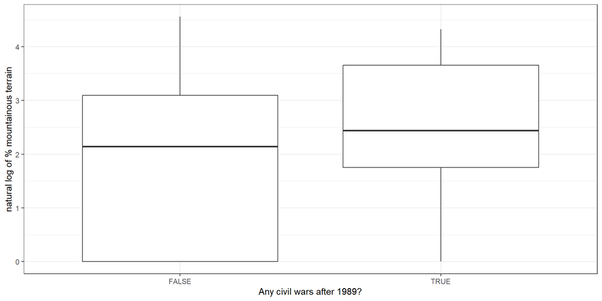

```r
ggplot(joined_data, aes(x=any_civil_war, y=rough)) +
  geom_boxplot() +
  theme_bw() +
  ylab("natural log of % mountainous terrain") +
  xlab("Any civil wars after 1989?")
```